# Peer Assessment 1

Alexey Agarkov

15 November 2015 г.

## Introduction

It is now possible to collect a large amount of data about personal movement using activity monitoring devices such as a Fitbit, Nike Fuelband, or Jawbone Up. These type of devices are part of the “quantified self” movement – a group of enthusiasts who take measurements about themselves regularly to improve their health, to find patterns in their behavior, or because they are tech geeks. But these data remain under-utilized both because the raw data are hard to obtain and there is a lack of statistical methods and software for processing and interpreting the data.

This assignment makes use of data from a personal activity monitoring device. This device collects data at 5 minute intervals through out the day. The data consists of two months of data from an anonymous individual collected during the months of October and November, 2012 and include the number of steps taken in 5 minute intervals each day.

## Data

The data for this assignment can be downloaded from the course web site:

Dataset: https://d396qusza40orc.cloudfront.net/repdata%2Fdata%2Factivity.zip [52K] The variables included in this dataset are:

- steps: Number of steps taking in a 5-minute interval (missing values are coded as NA)
- date: The date on which the measurement was taken in YYYY-MM-DD format
- interval: Identifier for the 5-minute interval in which measurement was taken

The dataset is stored in a comma-separated-value (CSV) file and there are a total of 17,568 observations in this dataset.

## Getting the data

Getting the data includes:

- downloading a file;
- extracting .csv from a .zip archive;
- and reading it into current workspace.

```r
temp <- tempfile()
download.file("https://d396qusza40orc.cloudfront.net/repdata%2Fdata%2Factivity.zip",
              temp)
table_raw <- read.table(unz(temp, "activity.csv"),
                        header = T,
                        sep = ",",
                        stringsAsFactors = F,
                        na.strings="?")
unlink(temp)
rm(temp)
```

The raw untreated data is kept in **table_raw** data frame. Any processing will be performed ad hoc for each question.

## Part 1: What is mean total number of steps taken per day?

In order to address the question the data needs to be processed.

Processing involves:

- grouping by dates;
- summarizing number of steps taken per day;
- subsetting the available data.

```r
#Processing data
daily_steps <- table_raw
daily_steps$steps <- as.numeric(daily_steps$steps)

daily_steps <- daily_steps %>%
  select(date, steps) %>%
  group_by(date) %>%
  summarise(Total.steps = sum(steps, na.rm = T)) %>%
  subset(Total.steps > 0)
```

The total number of steps taken per day has been just calculated. So now the data is ready for further analysis.

First chunk of code produces a histogram, which roughly estimates the frequency distribution of number of steps taken per day. Here’s the code for the histogram.

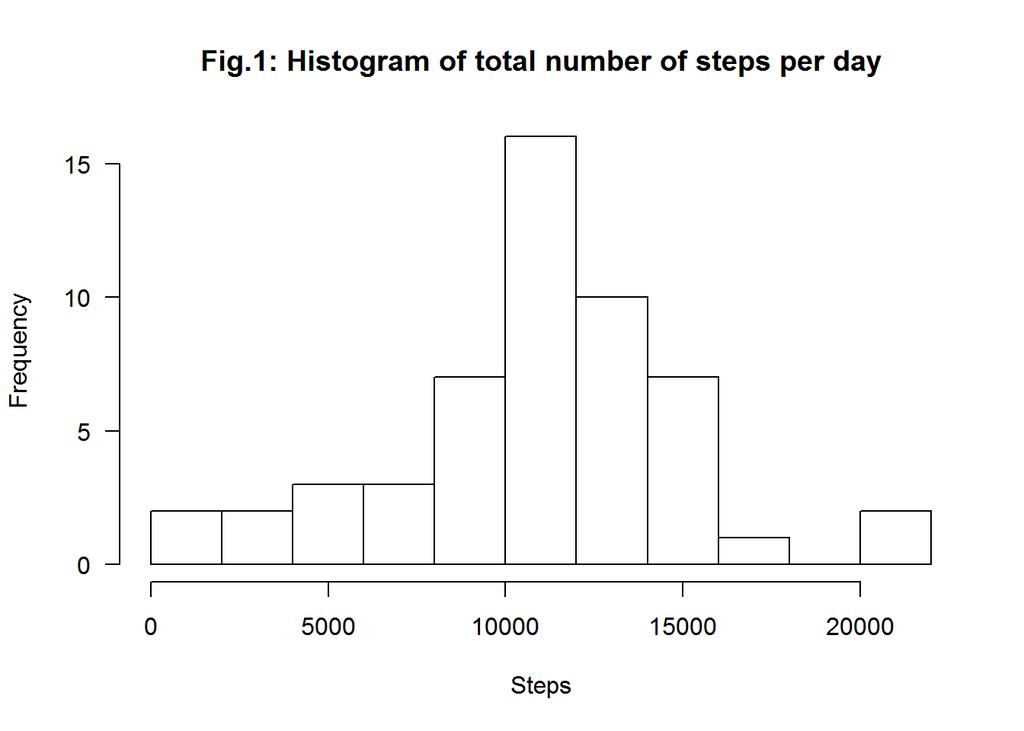

```r
hist(daily_steps$Total.steps,
     main = "Fig.1: Histogram of total number of steps per day",
     xlab = "Steps",
     breaks = 10,
     las=1)
```

Now it’s time to calculate the mean and median of the total number of steps taken per day. The code is as follows.

```r
mean_steps <- round(mean(daily_steps$Total.steps), digits = 2)
median_steps <- round(median(daily_steps$Total.steps), digits = 2)
```

So the mean of the total number of steps taken per day is:

```
## 10766.19
```

And the median is:

```
## 10765
```

## Part 2: What is the average daily activity pattern?

Proccessing for this step involves groupping by 5-minute interval across all dates.

```r
#Processing data
activity_pattern <- table_raw
activity_pattern$steps <- as.numeric(activity_pattern$steps)

activity_pattern <- activity_pattern %>%
  select(interval, steps) %>%
  group_by(interval) %>%
  summarise(mean.steps = mean(steps, na.rm = T))
```

Once the data has been prepared, a time series plot of the 5-minute intervals (across x-axis) and the average number of steps taken, averaged across all days (y-axis) can be constructed.

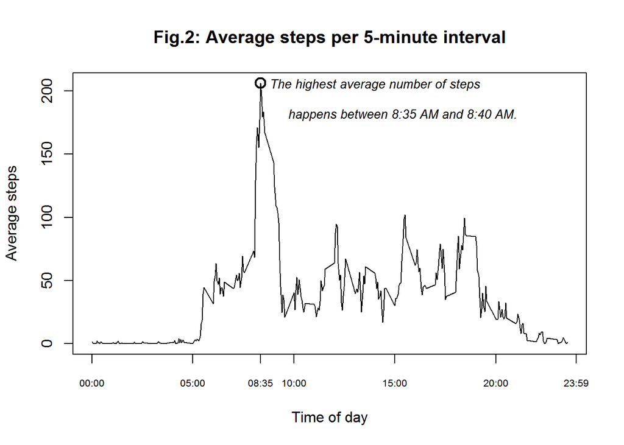

```r
plot(activity_pattern$interval, activity_pattern$mean.steps, type = "l",
    main = "Fig.2: Average steps per 5-minute interval",
    ylab = "Average steps", xlab = "Time of day", xaxt = "n")
axis(side = 1,
     labels = c("00:00", "05:00", "08:35", "10:00", "15:00", "20:00", "23:59"),
     at = c(0, 500, 835, 1000, 1500, 2000, 2399),
     cex.axis = 0.65)
text(835 + 0.9, max(activity_pattern$mean.steps)-15, "The highest average number of steps \n
     happens between 8:35 AM and 8:40 AM.", cex=0.85, font=3, pos=4)
symbols(835, max(activity_pattern$mean.steps), circles=25, inches=FALSE, add=TRUE, lwd=2)
```

Now it’s time to find the interval with the highest average number of steps.

```r
max_average_steps <- max(activity_pattern$mean.steps)
max_interval <- activity_pattern$interval[activity_pattern$mean.steps == max_average_steps]
```

Since the interval has a value of 835, it means that the highest average number of steps is taken between 8:35 AM and 8:40 AM.

## Part 3: Imputing missing values

Here’s a line of code which calculates missing values:

```r
NA_count <- sum(is.na(as.numeric(table_raw$steps)))
```

There are 2304 missing values.

As a strategy for filling missing values I would like to impute missing data points with mean values of corresponding 5-minute interval. Since the mean for every interval has already been calculated in previous part and is available in **activity_pattern** data frame it seems reasonable to use it. The code creates a new **table** data frame and matches NA data points by intervals with **activity_pattern** data frame.

```r
table <- table_raw
table$steps <- as.numeric(table$steps)
table$steps[is.na(table$steps)] <- activity_pattern$mean.steps[
                                    match(table$interval[is.na(table$steps)],
                                    activity_pattern$interval)]
```

Operations in the next step will be similar to part 1:

- dataset is grouping by days;
- number of steps taken per day is calculated.

```r
daily_steps_imp <- table %>%
  select(date, steps) %>%
  group_by(date) %>%
  summarise(Total.steps = sum(steps, na.rm = T))
```

And here’s a histogram.

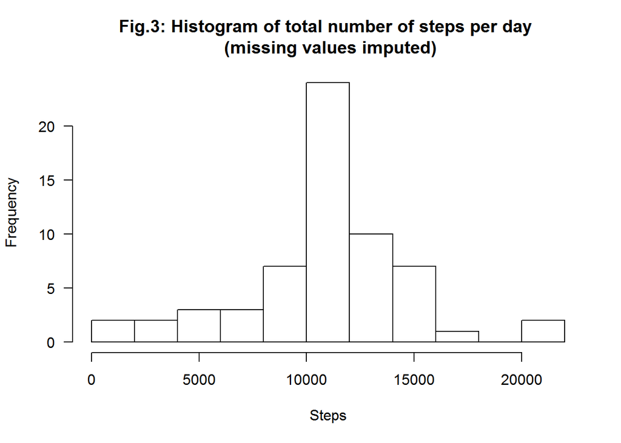

```r
hist(daily_steps_imp$Total.steps,
     main = "Fig.3: Histogram of total number of steps per day \n (missing values imputed)",
     xlab = "Steps",
     breaks = 10,
     las=1)
```

Mean and median calculations for updated data.

```r
mean_steps_imp <- round(mean(daily_steps_imp$Total.steps), digits = 2)
median_steps_imp <- round(median(daily_steps_imp$Total.steps), digits = 2)
```

The mean of the total number of steps taken per day for updated data is:

```
## 10766.19
```

Since the data has been updated with means a new median is equal to mean:

```
## 10766.19
```

The strategy used for imputing missing data had no significatng impact on the steps per day frequency distribution, mean and median.

## Part 4: Are there differences in activity patterns between weekdays and weekends?

For this part of assignment a dataset must be updated with variable, indicating a day of the week, which will help to distinguish between weekends and weekdays.

```r
table_weekdays <- table
table_weekdays$date <- strptime(table_weekdays$date, format = "%Y-%m-%d")
table_weekdays$Wday <- weekdays(table_weekdays$date)
table_weekdays$Wday <- gsub("Monday", "Weekday",
                            table_weekdays$Wday)
table_weekdays$Wday <- gsub("Tuesday", "Weekday",
                            table_weekdays$Wday)
table_weekdays$Wday <- gsub("Wednesday", "Weekday",
                            table_weekdays$Wday)
table_weekdays$Wday <- gsub("Thursday", "Weekday",
                            table_weekdays$Wday)
table_weekdays$Wday <- gsub("Friday", "Weekday",
                            table_weekdays$Wday)
table_weekdays$Wday <- gsub("Saturday", "Weekend",
                            table_weekdays$Wday)
table_weekdays$Wday <- gsub("Sunday", "Weekend",
                            table_weekdays$Wday)
```

After the weekday variable has been defined, it’s time for further processing. Activity patterns for weekday/weekend should be worked out, similarly to part 2.

```r
weekdays_activity_pattern <- table_weekdays %>%
  select(Wday, interval, steps) %>%
  group_by(Wday, interval) %>%
  summarise(mean.steps = mean(steps))

weekdays <- subset(weekdays_activity_pattern, weekdays_activity_pattern$Wday == "Weekday")
weekends <- subset(weekdays_activity_pattern, weekdays_activity_pattern$Wday == "Weekend")
```

The panel plot to compare the activity between weekdays.

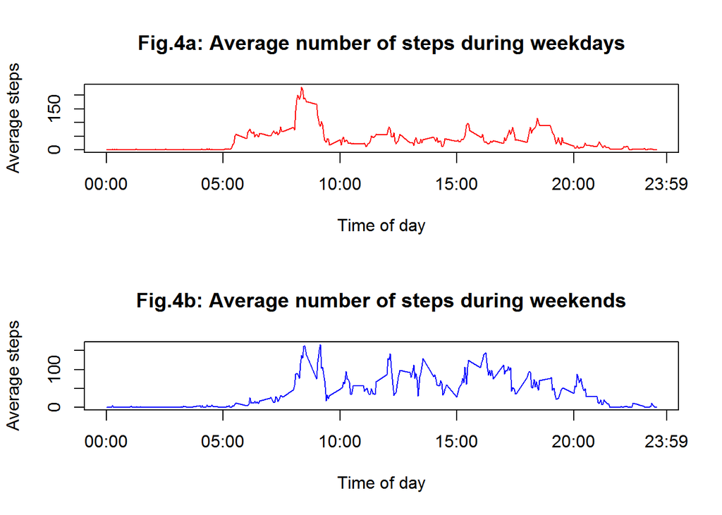

```r
par <- par(mfrow = c(2, 1))
plot(weekdays$interval,
     weekdays$mean.steps,
     type = "l", col = "red", ylab = "Average steps", xlab = "Time of day",
     main = "Fig.4a: Average number of steps during weekdays", xaxt = "n")
axis(side = 1,
     labels = c("00:00", "05:00", "10:00", "15:00", "20:00", "23:59"),
     at = c(0, 500, 1000, 1500, 2000, 2399))

plot(weekends$interval,
     weekends$mean.steps,
     type = "l", col = "blue", ylab = "Average steps", xlab = "Time of day",
     main = "Fig.4b: Average number of steps during weekends", xaxt = "n")
axis(side = 1,
     labels = c("00:00", "05:00", "10:00", "15:00", "20:00", "23:59"),
     at = c(0, 500, 1000, 1500, 2000, 2399))
```

In order to facilitate the comparison a single plot could be used.

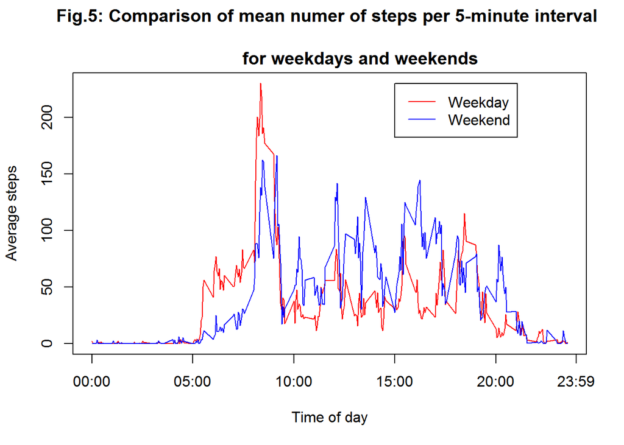

```r
plot(weekdays$interval,
     weekdays$mean.steps,
     type = "l", col = "red", ylab = "Average steps", xlab = "Time of day",
     main = "Fig.5: Comparison of mean numer of steps per 5-minute interval \n
            for weekdays and weekends", xaxt = "n")
axis(side = 1,
     labels = c("00:00", "05:00", "10:00", "15:00", "20:00", "23:59"),
     at = c(0, 500, 1000, 1500, 2000, 2399))
lines(weekends$interval, weekends$mean.steps, type = "l",
     col = "blue")
legend(x = 1500, y = 230,
       c("Weekday", "Weekend"),
       col = c("red", "blue"),
       lty = c(1, 1),
       lwd = c(1, 1))
```